# Completely Randomized Design (CRD): ANOVA Basics

Analysis of Variance Fundamentals

Dr. Samuel B Fernandes

2026-01-01

## Learning Objectives

By the end of this lecture, you should be able to:

- Explain when and why to use a completely randomized design for experiments
- Design a CRD
- Describe the statistical model for CRD: $y_{ij} = \mu + \tau_i + \varepsilon_{ij}$
- Construct and interpret an ANOVA table for a one-way CRD

## Review: Why Randomization?

- **Monday’s lecture:** Randomization eliminates bias and ensures valid statistical inference
- **Wednesday’s lecture:** True (biological) replication vs Pseudo (technical) replication (i.e., experimental vs observational unit)
- **Today’s question:** Once we randomize and collect data, how do we analyze it?

**Randomization is the foundation of experimental design, but ANOVA is the tool for analysis.**

# What is a CRD?

## CRD: When and Why

**Completely Randomized Design (CRD):**

- Simplest experimental design
- Treatments assigned **completely at random** to all experimental units
- **Assumption:** All units are homogeneous (no known gradients or blocks)
- **Best for:** Controlled environments (growth chambers, labs, homogeneous fields)

**When NOT to use CRD:**

- Field trials with soil gradients
- Greenhouse trials with bench effects
- Any situation with known nuisance variation → Use blocking instead (next week!)

Randomization snapshot

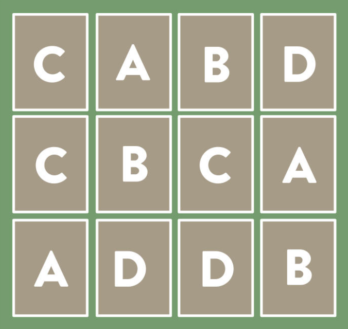

CRD Randomization

All 12 plots receive treatments purely by chance

## Agricultural Example: Nitrogen on Wheat

**Research Question:**  
Do different nitrogen fertilizer rates affect wheat yield?

**Experimental Setup:**

- **Treatments:** 4 nitrogen rates (0, 50, 100, 150 kg N/ha)
- **Experimental Units:** 24 field plots (assumed homogeneous)
- **Replicates:** [____]plots per treatment
- **Response Variable:** Grain yield (kg/ha)
- **Design:** Completely Randomized Design (CRD)

**Null Hypothesis:**  
$H_0: \tau_1 = \tau_2 = \tau_3 = \tau_4 = 0$ (No treatment effects; all treatments have the same mean yield)

**Alternative Hypothesis:**  
$H_a:$ At least one $\tau_i \neq 0$ (At least one treatment differs)

# CRD Layout and Randomization

## Generating the Randomized Layout

```r
library(dplyr)
library(ggplot2)
library(FielDHub)
```

**Using FielDHub package:**

```r
# Generate CRD layout
crd_design <- CRD(
    t = 4, # Number of treatments
    reps = 6, # Replicates per treatment
    plotNumber = 1, # Starting plot number
    seed = 2026, # Reproducibility
    locationName = "Fayetteville",
    data = data.frame(
        Treatment = c("N0", "N50", "N100", "N150"),
        Reps = 6
    )
)

# Extract field book
field_book <- crd_design$fieldBook
head(field_book, 10)
```

```
#>    ID     LOCATION PLOT REP TREATMENT
#> 1   1 Fayetteville    1   1        N0
#> 2   2 Fayetteville    2   6       N50
#> 3   3 Fayetteville    3   2      N100
#> 4   4 Fayetteville    4   6        N0
#> 5   5 Fayetteville    5   2       N50
#> 6   6 Fayetteville    6   2        N0
#> 7   7 Fayetteville    7   5      N150
#> 8   8 Fayetteville    8   1      N100
#> 9   9 Fayetteville    9   6      N100
#> 10 10 Fayetteville   10   5       N50
```

## Using the FielDHub Shiny app (no code needed)

- Launch the app in RStudio or VScode: it opens a browser
- Choose **Completely Randomized Design (CRD)**, set **Treatments = 4**, **Replicates = 6**, **Start plot = 1**, and **Seed = 2026**.
- Click **Run randomization**, then check the **Field Book** tab for assignments and the **Layout** tab for the grid view.
- Export your layout or field book with the **Download** buttons to share with your team.

```r
# Launch the interactive FielDHub Shiny app (run locally in RStudio)
FielDHub::run_app() #or
library(FieldHub)
run_app()
```

## Visualizing the CRD Layout

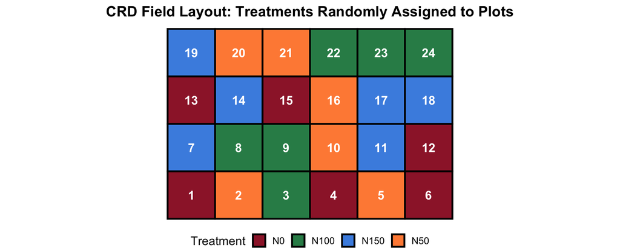

Figure 1: Completely Randomized Design: 4 nitrogen treatments × 6 replicates

```r
# Add grid coordinates for visualization
field_book <- field_book |>
    mutate(
        row = rep(1:4, each = 6),
        col = rep(1:6, times = 4)
    )

ggplot(field_book, aes(x = col, y = row, fill = TREATMENT)) +
    geom_tile(color = "black", linewidth = 1) +
    geom_text(aes(label = PLOT), color = "white", size = 5, fontface = "bold") +
    scale_fill_manual(values = c(
        "N0" = "#9D2235",
        "N50" = "#FF8C42",
        "N100" = "#2E8B57",
        "N150" = "#4A90E2"
    )) +
    labs(
        title = "CRD Field Layout: Treatments Randomly Assigned to Plots",
        x = "Column",
        y = "Row",
        fill = "Treatment"
    ) +
    theme_void(base_size = 14) +
    theme(
        legend.position = "bottom",
        plot.title = element_text(hjust = 0.5, face = "bold")
    ) +
    coord_equal()
```

# Statistical Model for CRD

## The CRD Model

**In plain English:**

- Observed yield = grand mean + treatment effect + random noise
- Treatment effect $\tau_i$ could be positive (increases yield) or negative (decreases yield)
- Error $\varepsilon_{ij}$ captures plot-to-plot variation (weather, soil micro-variation, measurement error)

**CRD Model:**
$$y_{ij} = \mu + \tau_i + \varepsilon_{ij}$$

Where:

- $y_{ij}$ = Observed response for treatment $i$, replicate $j$
- $\mu$ = Overall mean (grand mean)
- $\tau_i$ = Effect of treatment $i$ (what we want to estimate)
- $\varepsilon_{ij}$ = Random error term $\sim N(0, \sigma^2)$

## Model Assumptions

1. **Independence:** Observations are independent (randomization ensures this)
2. **Normality:** Errors $\varepsilon_{ij}$ are normally distributed
3. **Homogeneity of Variance:** Errors have constant variance $\sigma^2$ across all treatments

**Why these assumptions matter:**

- **Normality:** Ensures F-test is valid (though ANOVA is robust to mild violations with balanced designs)
- **Equal variance:** Prevents treatment comparisons from being biased by different noise levels
- **Independence:** Broken if plots influence each other (e.g., pest movement, water runoff)

**Important:** We’ll test these assumptions next lecture with diagnostic plots. For now, understand what ANOVA requires.

# ANOVA: Analysis of Variance

## The Core Idea of ANOVA

**ANOVA asks:** Is the variation **between treatments** larger than the variation **within treatments**?

**Total Variation = Treatment Variation + Error Variation**

$$SS_{Total} = SS_{Treatment} + SS_{Error}$$

**If treatments differ:**

- Between-group variation is LARGE
- Within-group variation is small.
- F-statistic is large → reject $H_0$

**If treatments are the same:**

- Between-group variation is small
- Comparable to within-group variation
- F-statistic is small → fail to reject $H_0$

## ANOVA Table Structure

| Source | df | Sum of Squares | Mean Square | F-statistic | p-value |
| --- | --- | --- | --- | --- | --- |
| Treatment | $t-1$ | $SS_{Trt}$ | $MS_{Trt} = \frac{SS_{Trt}}{t-1}$ | $F = \frac{MS_{Trt}}{MS_{Error}}$ | P(F > observed) |
| Error | $t(r-1)$ | $SS_{Error}$ | $MS_{Error} = \frac{SS_{Error}}{t(r-1)}$ | — | — |
| **Total** | $tr-1$ | $SS_{Total}$ | — | — | — |

**Key formulas:**

- $SS_{Total} = \sum_{i,j} (y_{ij} - \bar{y}_{..})^2$ (total deviation from grand mean)
- $SS_{Treatment} = r \sum_i (\bar{y}_{i.} - \bar{y}_{..})^2$ (deviation of treatment means from grand mean)
- $SS_{Error} = SS_{Total} - SS_{Treatment}$ (leftover variation)

## Interpreting the F-test

**F-statistic:**
$$F = \frac{MS_{Treatment}}{MS_{Error}} = \frac{\text{Variation between treatments}}{\text{Variation within treatments}}$$

- Large F → treatments explain more variation than random error → likely significant
- Small F → treatment variation is comparable to error → not significant
- **p-value:** Probability of observing this F (or larger) if $H_0$ is true

**Decision rule:**

- If p-value < $\alpha$ (usually 0.05): Reject $H_0$ → At least one treatment differs
- If p-value ≥ $\alpha$: Fail to reject $H_0$ → No evidence of treatment differences

**Remember:** A significant F-test tells you “some treatments differ” but NOT which ones. Post-hoc tests (next week) identify specific differences.

# R Code Demo

## Simulating CRD Data

```r
set.seed(2026)

# Simulate wheat yield data (kg/ha)
# True means: N0=2400, N50=2650, N100=2900, N150=2950
# Error SD = 150
crd_data <- field_book |>
    mutate(
        true_mean = case_when(
            TREATMENT == "N0" ~ 2400,
            TREATMENT == "N50" ~ 2650,
            TREATMENT == "N100" ~ 2900,
            TREATMENT == "N150" ~ 2950
        ),
        yield = true_mean + rnorm(n(), mean = 0, sd = 150)
    ) |>
    select(PLOT, TREATMENT, REP, yield)

head(crd_data, 8)
```

```
#>   PLOT TREATMENT REP    yield
#> 1    1        N0   1 2478.088
#> 2    2       N50   6 2488.046
#> 3    3      N100   2 2920.886
#> 4    4        N0   6 2387.288
#> 5    5       N50   2 2550.004
#> 6    6        N0   2 2022.587
#> 7    7      N150   5 2839.728
#> 8    8      N100   1 2746.982
```

## Visualizing Treatment Means

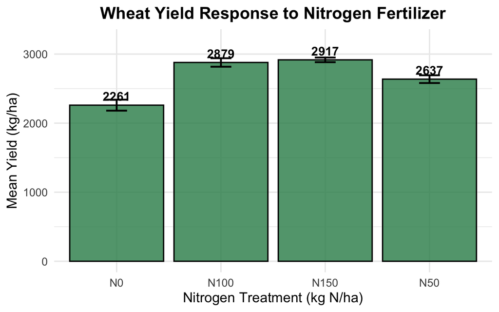

Figure 2: Mean wheat yield by nitrogen treatment with standard error bars

```r
# Calculate means and SEs
treatment_summary <- crd_data |>
    group_by(TREATMENT) |>
    summarize(
        mean_yield = mean(yield),
        se_yield = sd(yield) / sqrt(n()),
        .groups = "drop"
    )

ggplot(treatment_summary, aes(x = TREATMENT, y = mean_yield)) +
    geom_col(fill = "#2E8B57", alpha = 0.8, color = "black") +
    geom_errorbar(
        aes(
            ymin = mean_yield - se_yield,
            ymax = mean_yield + se_yield
        ),
        width = 0.2, linewidth = 1
    ) +
    geom_text(aes(label = round(mean_yield, 0)),
        vjust = -0.5, size = 5, fontface = "bold"
    ) +
    labs(
        title = "Wheat Yield Response to Nitrogen Fertilizer",
        x = "Nitrogen Treatment (kg N/ha)",
        y = "Mean Yield (kg/ha)"
    ) +
    theme_minimal(base_size = 16) +
    theme(
        plot.title = element_text(hjust = 0.5, face = "bold")
    ) +
    ylim(0, 3200)
```

## Fitting the ANOVA Model in R

```r
# Fit linear model
model_crd <- aov(yield ~ TREATMENT, data = crd_data)

# ANOVA table
anova(model_crd)
```

```
#> Analysis of Variance Table
#>
#> Response: yield
#>           Df  Sum Sq Mean Sq F value    Pr(>F)
#> TREATMENT  3 1637754  545918  25.173 5.392e-07 ***
#> Residuals 20  433733   21687
#> ---
#> Signif. codes:  0 '***' 0.001 '**' 0.01 '*' 0.05 '.' 0.1 ' ' 1
```

## ANOVA Table Breakdown

- Next step: Determine which treatments differ (post-hoc tests in Lecture 5)

# Your Turn Activity

## Interpret ANOVA Output

**Scenario:**  
A colleague tests 3 fungicide treatments (Control, FungA, FungB) on tomato disease severity (% leaf area infected). They run a CRD with 5 replicates per treatment (15 plants total).

**ANOVA Results:**

```
Analysis of Variance Table

Response: disease_severity
           Df  Sum Sq Mean Sq F value    Pr(>F)
Treatment   2  248.13  124.07  15.51 0.0006 ***
Residuals  12   96.00    8.00
---
Signif. codes:  0 '***' 0.001 '**' 0.01 '*' 0.05 '.' 0.1 ' ' 1
```

**Questions (3 minutes, think-pair-share):**

1. Are the fungicide treatments significantly different? How do you know?
2. What percentage of variation is explained by treatments? (Hint: $R^2 = \frac{SS_{Trt}}{SS_{Total}}$)
3. What should the researcher do next?

# Summary & Key Takeaways

## What We Learned Today

- **CRD** is the simplest experimental design: treatments assigned completely at random
- Best for **homogeneous** experimental units (no gradients)
- **CRD Model:** $y_{ij} = \mu + \tau_i + \varepsilon_{ij}$
- **ANOVA** partitions variation: Total = Treatment + Error
- **F-test** asks: Is treatment variation larger than error variation?
- Significant F-test → at least one treatment differs (but doesn’t say which!)
- **R workflow:** Generate design with FielDHub → Fit model with `aov()` → ANOVA table with `anova()`

**You now know how to design, randomize, and analyze a completely randomized experiment!**

## Next Lecture Preview

**Friday (Lecture 4): CRD Assumptions & Diagnostics**

- How to check ANOVA assumptions (normality, equal variance, independence)
- Diagnostic plots: Q-Q plots, residual plots
- What to do when assumptions are violated (transformations)
- Bring questions about today’s material!

**Tip**

**Homework suggestion:** Re-run today’s R code with different random seeds. See how randomization affects results (but conclusions remain similar).

## Resources

**Textbook:**

- Oehlert (2010), *A First Course in Design and Analysis of Experiments*, **Chapter 2 (Part 1)**
  - Section 2.1: One-way classification
  - Section 2.2: CRD model and assumptions
  - Section 2.3: ANOVA F-test

**R Packages:**

- `FielDHub`: Generate agricultural experimental designs ([link](https://fieldhub.netlify.app/))
- `car`: Type III ANOVA for unbalanced designs
- `emmeans`: Estimated marginal means and post-hoc tests
- `ggplot2`: Data visualization

**Additional Reading:**

- Montgomery (2017), *Design and Analysis of Experiments*, Chapter 3
- Doncaster & Davey (2007), *Analysis of Variance and Covariance*, Chapter 2